# Relatório

Andrews HIlder Fontenelle Leão

21/04/2021

# Carregar pacotes

```r
library(readxl)
library(dplyr)
library(rmarkdown)
library(carData)
library(car)
library(ggplot2)
library(corrplot)
library(lmtest)
library(psych)
library(vegan)
```

## Importar banco de dados

Os dados foram importados usando a função “read_excel” e logo após serem importados, foram verificados a partir da função “glimpse” que apresenta um resumo dos dados importados

```r
cerveja2_0 <- read_excel("C:/Users/andre/Desktop/cerveja2.0.xlsx",
    na = "NA")

glimpse(cerveja2_0)
```

```
## Rows: 365
## Columns: 8
## $ mês   <chr> "Jan", "Jan", "Jan", "Jan", "Jan", "Jan", "Jan", "Jan", "Jan", "~
## $ Data  <dttm> 2019-01-01, 2019-01-02, 2019-01-03, 2019-01-04, 2019-01-05, 201~
## $ Tmed  <dbl> 27.30, 27.02, 24.82, 23.98, 23.82, 23.78, 24.00, 24.90, 28.20, 2~
## $ Tmin  <dbl> 23.9, 24.5, 22.4, 21.5, 21.0, 20.1, 19.5, 19.5, 21.9, 22.1, 22.2~
## $ Tmax  <dbl> 32.5, 33.5, 29.9, 28.6, 28.3, 30.5, 33.7, 32.8, 34.0, 34.2, 34.8~
## $ Sprec <dbl> 0.0, 0.0, 0.0, 1.2, 0.0, 12.2, 0.0, 48.6, 4.4, 0.0, 3.4, 0.0, 0.~
## $ dia   <chr> "úteis", "úteis", "FDS", "FDS", "úteis", "úteis", "úteis", "útei~
## $ CC    <dbl> 25461, 28972, 30814, 29799, 28900, 28218, 29732, 28397, 24886, 3~
```

## Leitura e visualização do banco de dados

Com os dados em mãos, é possível observar as colunas presentes, que representam as seguintes variáveis: Mês Data: com valores de: dia, mês e ano Tmed: Temperatura média Tmin: Temperatura mínima Tmax: Temperatura máxima Sprec:Precipitação diária Dia: Dia útil ou fim de semana CC: consumo de cerveja

```r
paged_table(cerveja2_0)
```

| mês | Data | Tmed | Tmin | Tmax | Sprec | dia | CC |
| --- | --- | --- | --- | --- | --- | --- | --- |
| Jan | 2019-01-01 | 27.30 | 23.9 | 32.5 | 0.0 | úteis | 25461 |
| Jan | 2019-01-02 | 27.02 | 24.5 | 33.5 | 0.0 | úteis | 28972 |
| Jan | 2019-01-03 | 24.82 | 22.4 | 29.9 | 0.0 | FDS | 30814 |
| Jan | 2019-01-04 | 23.98 | 21.5 | 28.6 | 1.2 | FDS | 29799 |
| Jan | 2019-01-05 | 23.82 | 21.0 | 28.3 | 0.0 | úteis | 28900 |
| Jan | 2019-01-06 | 23.78 | 20.1 | 30.5 | 12.2 | úteis | 28218 |
| Jan | 2019-01-07 | 24.00 | 19.5 | 33.7 | 0.0 | úteis | 29732 |
| Jan | 2019-01-08 | 24.90 | 19.5 | 32.8 | 48.6 | úteis | 28397 |
| Jan | 2019-01-09 | 28.20 | 21.9 | 34.0 | 4.4 | úteis | 24886 |
| Jan | 2019-01-10 | 26.76 | 22.1 | 34.2 | 0.0 | FDS | 37937 |

[output cut: 355 more lines]

### Com os dados em mãos, algumas hipóteses foram formuladas.

Será que a variável dia (final de semana e dia útil) influencia na variável CC (consumo de cerveja), para responder a esta pergunta, foi realizado um teste T, com o intuíto de verificar possíveis diferenças entre os dois grupos (dias úteis e final de semana).

## Teste T

Na primeira etapa do teste, foi divido os dados em úteis (dias úteis) e FDS (final de semana), a partir da função “summary”

```r
summary(cerveja2_0$dia=="úteis")
```

```
##    Mode   FALSE    TRUE
## logical     104     261
```

```r
summary(cerveja2_0$dia=="FDS")
```

```
##    Mode   FALSE    TRUE
## logical     261     104
```

Com os dados separados, partiu-se para a normalidade com o Shapiro teste, que apresenta se os dados seguem uma distribuição normal a partir. A partir da observação do valor de p (>0,05), aceita-se a hipótese nula, de que os dados são normais

```r
shapiro.test(cerveja2_0$CC[cerveja2_0$dia=="úteis"])
```

```
##
##  Shapiro-Wilk normality test
##
## data:  cerveja2_0$CC[cerveja2_0$dia == "úteis"]
## W = 0.98984, p-value = 0.06494
```

```r
shapiro.test(cerveja2_0$CC[cerveja2_0$dia=="FDS"])
```

```
##
##  Shapiro-Wilk normality test
##
## data:  cerveja2_0$CC[cerveja2_0$dia == "FDS"]
## W = 0.98523, p-value = 0.3039
```

Sabendo que os dados são normais, segue-se para o teste T em si, nele observa-se que o valor de p foi significativo (p<0,04), ou seja, a hipótese alternativa foi confirmada, existe diferença no consumo de cerveja entre fim de semana e dia útil. Sendo o final de semana o que possui o maior consumo (vide o gráfico a seguir)

```r
t.test(cerveja2_0$CC~cerveja2_0$dia, var.equal=T)
```

```
##
##  Two Sample t-test
##
## data:  cerveja2_0$CC by cerveja2_0$dia
## t = 11.176, df = 363, p-value < 2.2e-16
## alternative hypothesis: true difference in means is not equal to 0
## 95 percent confidence interval:
##  4058.026 5790.972
## sample estimates:
##   mean in group FDS mean in group úteis
##            28922.72            23998.22
```

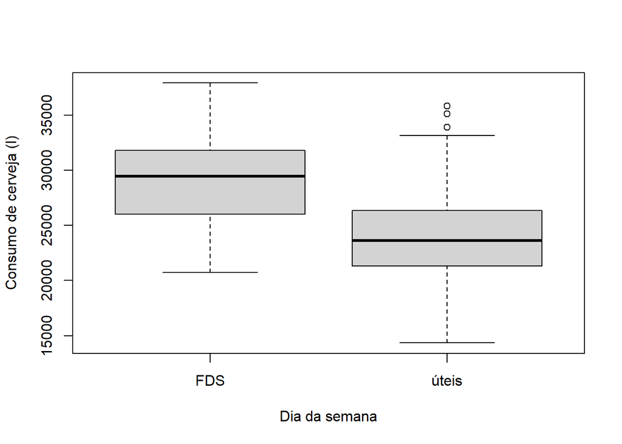

```r
par(mfrow=c(1,1))
boxplot(cerveja2_0$CC~cerveja2_0$dia, ylab = "Consumo de cerveja (l)", xlab = "Dia da semana")
```

Além da hipótese do fim de semana e dia útil, outra hipótese foi levantada. Qual das variáveis, restantes, imprime mais influência sob o consumo de cerveja. Para responder isso, foi realizado primeiro uma correlação, para verificar o quanto as variáveis em questão estavam associadas, inclusive com o consumo de cerveja

## Correlação

### Adicionar valores de média e inserir em células vazias

Primeiro, foram corrigidas falhas na base de dados, preenchendo áreas vazias e retirando possíveis valores muito discrepantes (outlier) (esses valores foram substituídos pela média da coluna)

```r
cerveja2_0$Tmed[which(cerveja2_0$Tmed == "52.86")]<-"21.12"
cerveja2_0$Tmed[which(is.na(cerveja2_0$Tmed))]<-"21.12"
cerveja2_0$Tmin[which(is.na(cerveja2_0$Tmin))]<-"17.47"
cerveja2_0$Tmax[which(is.na(cerveja2_0$Tmax))]<-"26.61"
cerveja2_0$Tmed<- as.double(cerveja2_0$Tmed)
cerveja2_0$Tmax<- as.double(cerveja2_0$Tmax)
cerveja2_0$Tmin<- as.double(cerveja2_0$Tmin)
```

### Log

Para tentar corrigir a anormalidade dos dados e reduzir os outliers, foi feito um log das variáveis numéricas

```r
cerveja <- decostand(cerveja2_0[,c(3,4,5,6,8)],"log")
head (cerveja)
```

```
##       Tmed     Tmin     Tmax    Sprec       CC
## 1 9.092757 8.900867 9.344296 0.000000 18.95793
## 2 9.077884 8.936638 9.388017 0.000000 19.14430
## 3 8.955359 8.807355 9.224002 0.000000 19.23323
## 4 8.905688 8.748193 9.159871 4.584963 19.18490
## 5 8.896030 8.714246 9.144658 0.000000 19.14071
## 6 8.893605 8.651052 9.252665 7.930737 19.10626
```

### Normalidade

```r
shapiro.test(cerveja$Tmed)
```

```
##
##  Shapiro-Wilk normality test
##
## data:  cerveja$Tmed
## W = 0.97991, p-value = 5.706e-05
```

```r
shapiro.test(cerveja$Tmin)
```

```
##
##  Shapiro-Wilk normality test
##
## data:  cerveja$Tmin
## W = 0.96522, p-value = 1.243e-07
```

```r
shapiro.test(cerveja$Tmax)
```

```
##
##  Shapiro-Wilk normality test
##
## data:  cerveja$Tmax
## W = 0.97383, p-value = 3.644e-06
```

```r
shapiro.test(cerveja$Sprec)
```

```
##
##  Shapiro-Wilk normality test
##
## data:  cerveja$Sprec
## W = 0.72255, p-value < 2.2e-16
```

```r
shapiro.test(cerveja$CC)
```

```
##
##  Shapiro-Wilk normality test
##
## data:  cerveja$CC
## W = 0.99287, p-value = 0.08005
```

### Presença de Outliers

Foram gerados gráficos de boxplot para verificar a presença ou não de outliers, onde foram vistos poucos destes

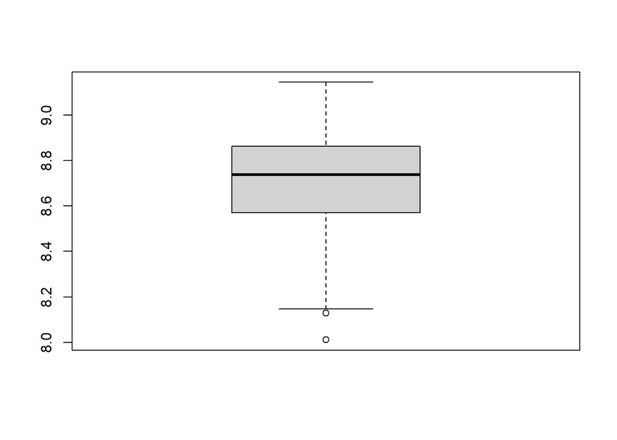

```r
boxplot(cerveja$Tmed)
```

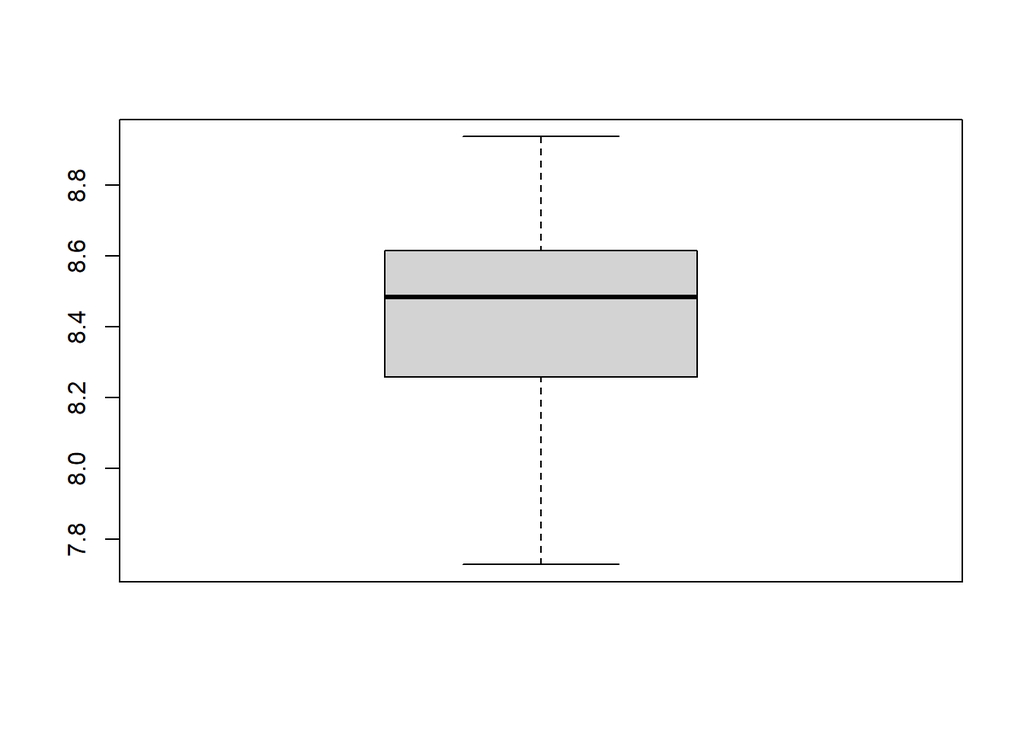

```r
boxplot(cerveja$Tmin)
```

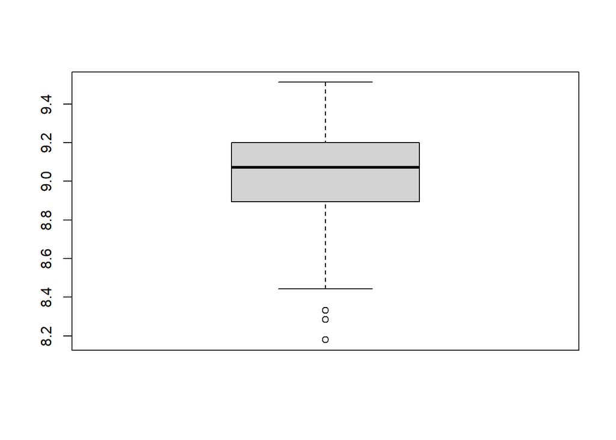

```r
boxplot(cerveja$Tmax)
```

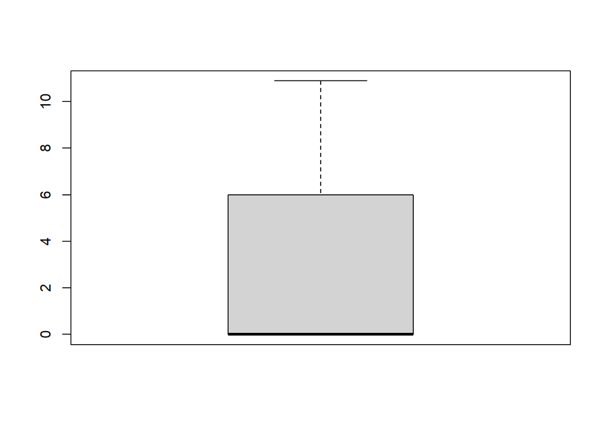

```r
boxplot(cerveja$Sprec)
```

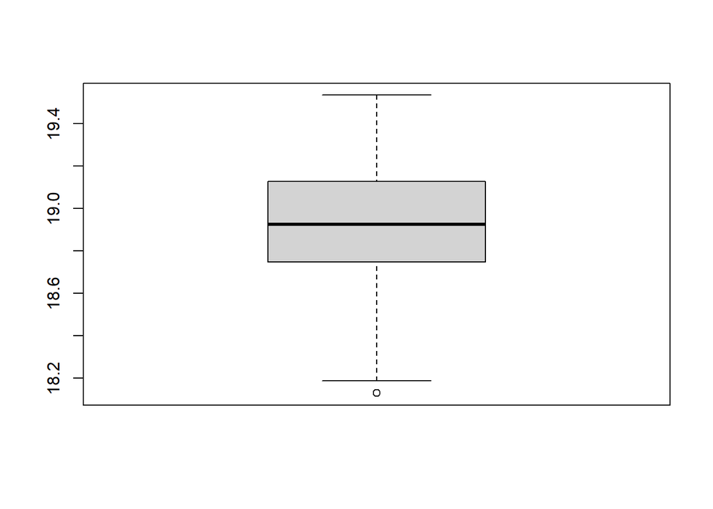

```r
boxplot(cerveja$CC)
```

### Construção do modelo O modelo foi construído para verificar se possuem homocedasticidade

```r
mod_reg1 <- lm(Tmed ~ Tmin, cerveja)
mod_reg2 <- lm(Tmed ~ Tmax, cerveja)
mod_reg3 <- lm(Tmed ~ Sprec, cerveja)
mod_reg4 <- lm(Tmed ~ CC, cerveja)

mod_reg5 <- lm(Tmin ~ Tmax, cerveja)
mod_reg6 <- lm(Tmin ~ Sprec, cerveja)
mod_reg7 <- lm(Tmin ~ CC, cerveja)

mod_reg8 <- lm(Tmax ~ Sprec, cerveja)
mod_reg9 <- lm(Tmax ~ CC, cerveja)

mod_reg10 <- lm(Sprec ~ CC, cerveja)
```

### Análise gráfica

A homocedasticidade, foi observada no gráfico, no geral seguiram o pressuposto apresentando os resíduos distribuídos uniformemente

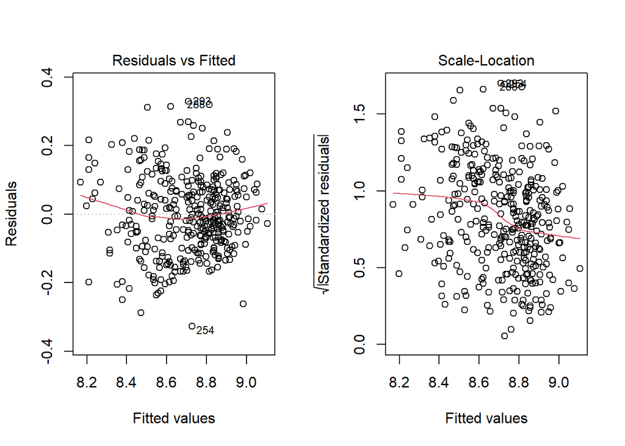

```r
par(mfrow=c(1,2))
plot(mod_reg1, which=c(1,3))
```

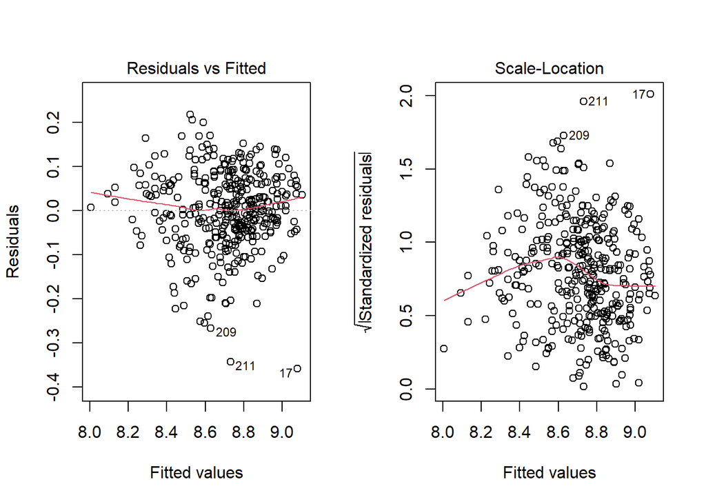

```r
plot(mod_reg2, which=c(1,3))
```

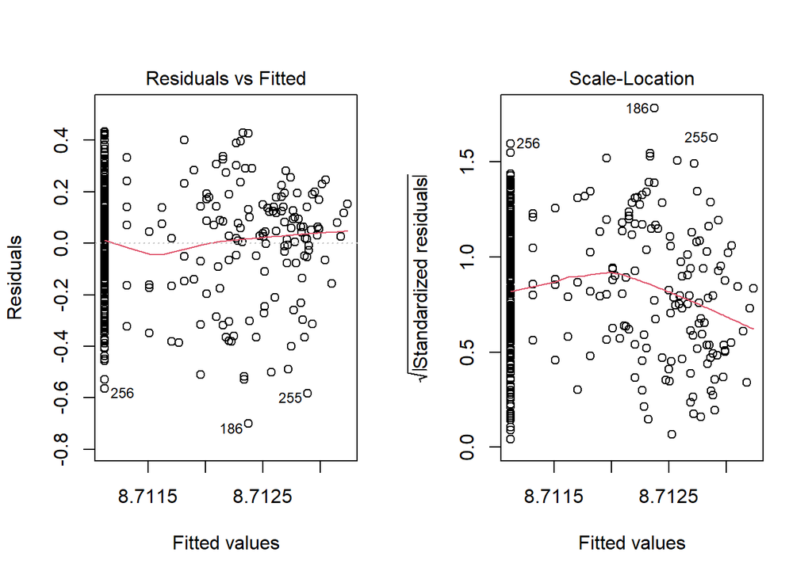

```r
plot(mod_reg3, which=c(1,3))
```

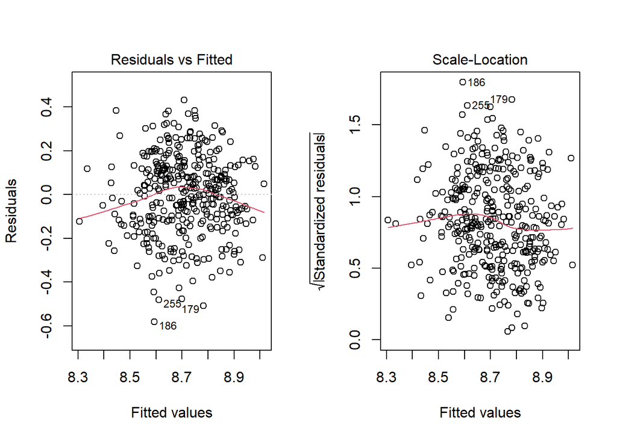

```r
plot(mod_reg4, which=c(1,3))
```

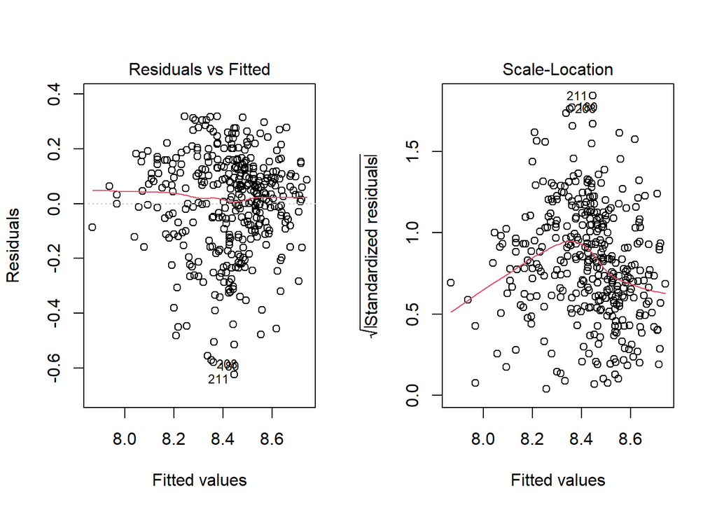

```r
plot(mod_reg5, which=c(1,3))
```

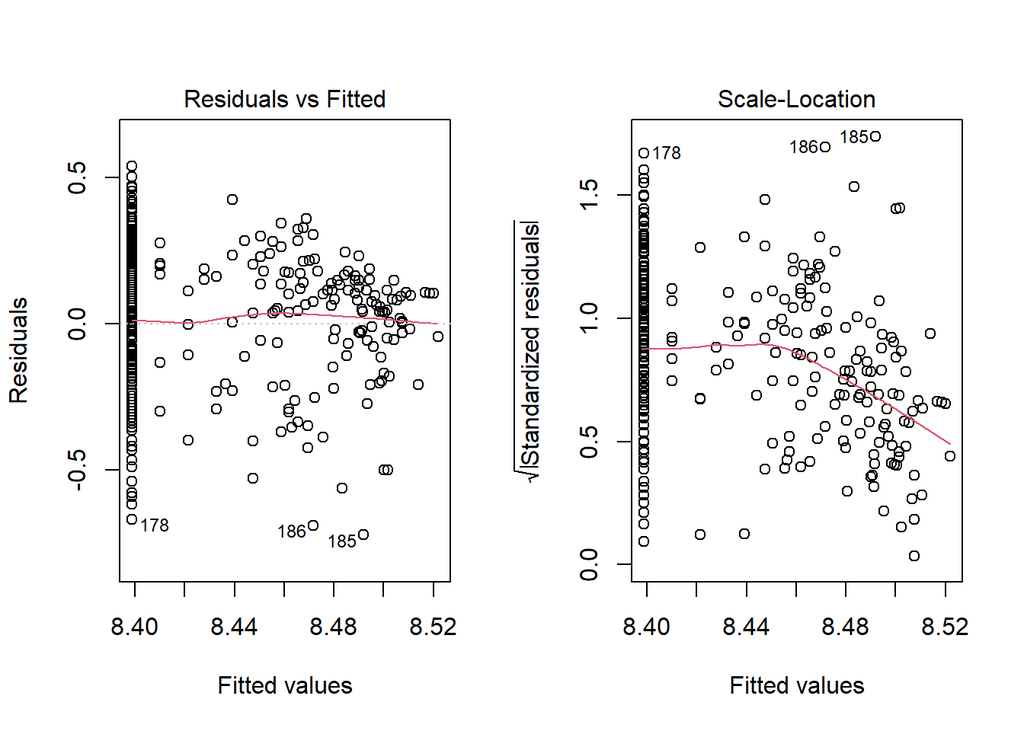

```r
plot(mod_reg6, which=c(1,3))
```

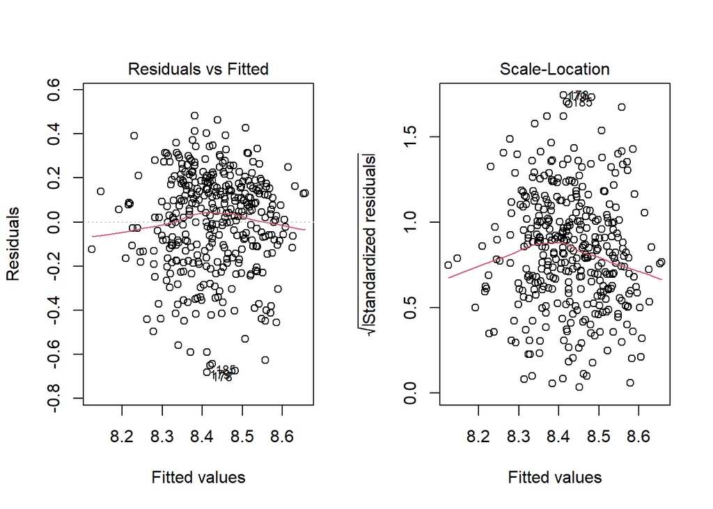

```r
plot(mod_reg7, which=c(1,3))
```

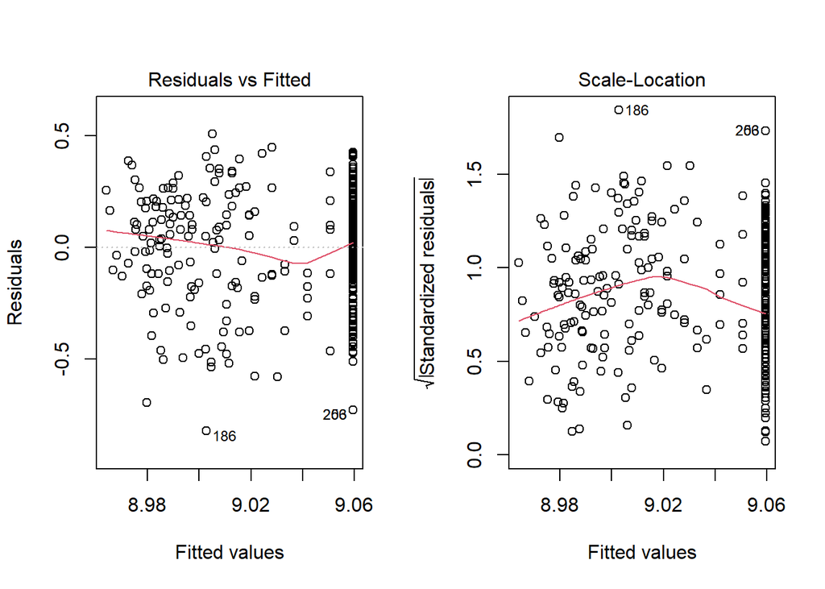

```r
plot(mod_reg8, which=c(1,3))
```

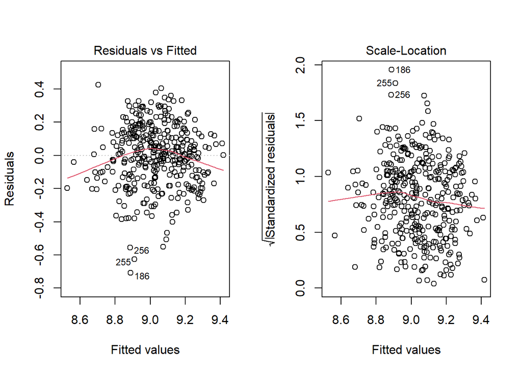

```r
plot(mod_reg9, which=c(1,3))
```

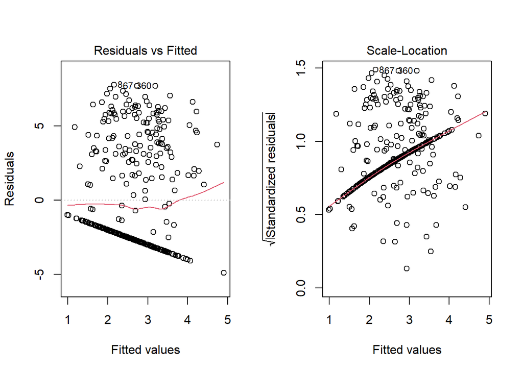

```r
plot(mod_reg10, which=c(1,3))
```

```r
par(mfrow=c(1,1))
```

Apesar de ter atendido os pressupostos da homocedasticidade, os dados não eram normais, por essa razão foi utilizado a correlação de spearman ### Correlação de Spearman Nesta, todos os valores apresentaram-se significativos, com excessão da temperatura média correlacionada à precipitação

```r
cor.test(cerveja$Tmed,cerveja$CC, method = "spearman")
```

```
##
##  Spearman's rank correlation rho
##
## data:  cerveja$Tmed and cerveja$CC
## S = 3538238, p-value < 2.2e-16
## alternative hypothesis: true rho is not equal to 0
## sample estimates:
##       rho
## 0.5634209
```

```r
cor.test(cerveja$Tmax,cerveja$CC, method = "spearman")
```

```
##
##  Spearman's rank correlation rho
##
## data:  cerveja$Tmax and cerveja$CC
## S = 2906040, p-value < 2.2e-16
## alternative hypothesis: true rho is not equal to 0
## sample estimates:
##       rho
## 0.6414271
```

```r
cor.test(cerveja$Tmin,cerveja$CC, method = "spearman")
```

```
##
##  Spearman's rank correlation rho
##
## data:  cerveja$Tmin and cerveja$CC
## S = 4950773, p-value = 1.21e-14
## alternative hypothesis: true rho is not equal to 0
## sample estimates:
##       rho
## 0.3891298
```

```r
cor.test(cerveja$Sprec,cerveja$CC, method = "spearman")
```

```
##
##  Spearman's rank correlation rho
##
## data:  cerveja$Sprec and cerveja$CC
## S = 9501515, p-value = 0.0009436
## alternative hypothesis: true rho is not equal to 0
## sample estimates:
##       rho
## -0.172381
```

```r
cor.test(cerveja$Tmed,cerveja$Tmin, method = "spearman")
```

```
##
##  Spearman's rank correlation rho
##
## data:  cerveja$Tmed and cerveja$Tmin
## S = 1154848, p-value < 2.2e-16
## alternative hypothesis: true rho is not equal to 0
## sample estimates:
##       rho
## 0.8575047
```

```r
cor.test(cerveja$Tmed,cerveja$Tmax, method = "spearman")
```

```
##
##  Spearman's rank correlation rho
##
## data:  cerveja$Tmed and cerveja$Tmax
## S = 754909, p-value < 2.2e-16
## alternative hypothesis: true rho is not equal to 0
## sample estimates:
##       rho
## 0.9068527
```

```r
cor.test(cerveja$Tmed,cerveja$Sprec, method = "spearman")
```

```
##
##  Spearman's rank correlation rho
##
## data:  cerveja$Tmed and cerveja$Sprec
## S = 7935489, p-value = 0.6914
## alternative hypothesis: true rho is not equal to 0
## sample estimates:
##       rho
## 0.0208492
```

```r
cor.test(cerveja$Tmin,cerveja$Tmax, method = "spearman")
```

```
##
##  Spearman's rank correlation rho
##
## data:  cerveja$Tmin and cerveja$Tmax
## S = 2746895, p-value < 2.2e-16
## alternative hypothesis: true rho is not equal to 0
## sample estimates:
##       rho
## 0.6610638
```

```r
cor.test(cerveja$Tmin,cerveja$Sprec, method = "spearman")
```

```
##
##  Spearman's rank correlation rho
##
## data:  cerveja$Tmin and cerveja$Sprec
## S = 6703716, p-value = 0.0009142
## alternative hypothesis: true rho is not equal to 0
## sample estimates:
##       rho
## 0.1728362
```

```r
cor.test(cerveja$Tmax,cerveja$Sprec, method = "spearman")
```

```
##
##  Spearman's rank correlation rho
##
## data:  cerveja$Tmax and cerveja$Sprec
## S = 9055283, p-value = 0.025
## alternative hypothesis: true rho is not equal to 0
## sample estimates:
##        rho
## -0.1173209
```

### Matriz de correlação

A partir deste gráfico foi possível observar a correlação das variáveis, umas com as outras, onde apresentou alta correlação entre as temperaturas máxima e média; e alta correlação entre temperatura máxima e consumo de cerveja. A partir destes resultados, foram escolhidas as variáveis temperatura máxima e miníma para a regressção com o consumo de cerveja. Apesar destas temperaturas serem correlatas, possuem bastante relevância sob o consumo de cerveja

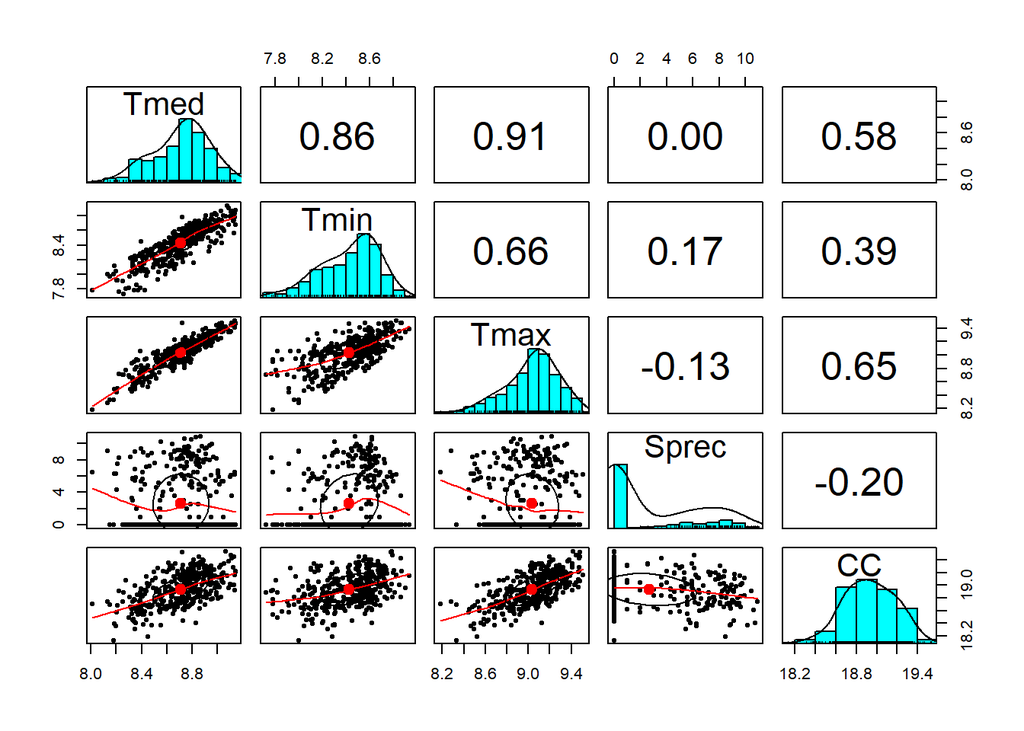

```r
pairs.panels(cerveja[,c(1,2,3,4,5)])
```

# Regressão ### Construção do modelo O modelo foi construído, utilizando as variáveis temperatura máxima e mínima como independentes e consumo de cerveja como dependente

```r
mod <- lm(CC ~ Tmax + Tmin,data=cerveja)
```

### Análise gráfica

Foram observadas: linearidade;resíduos com distribuição, aparentemente normal;apresenta homocedasticidade; e poucos outliers.

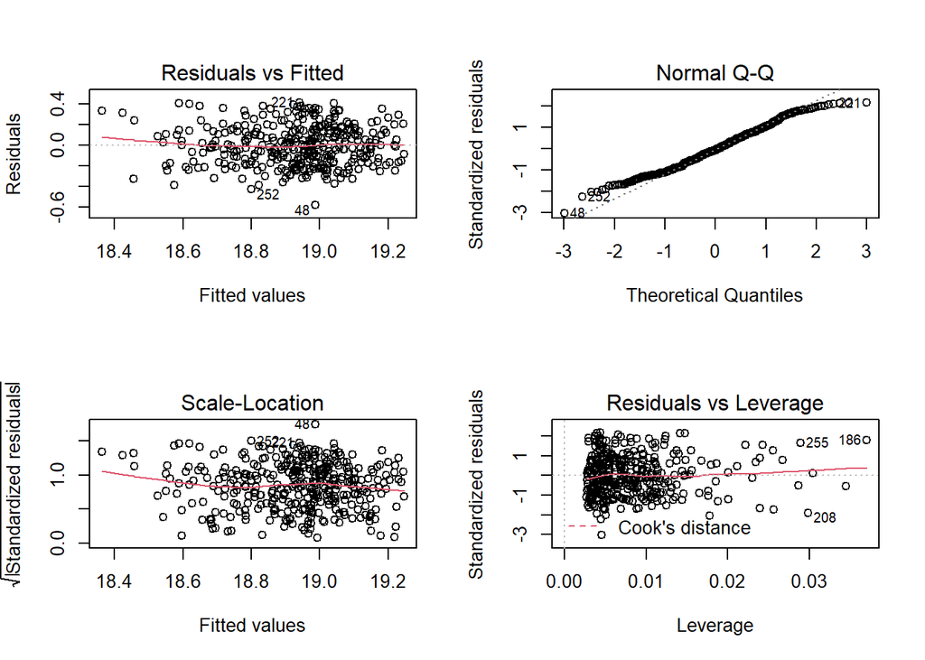

```r
par(mfrow=c(2,2))

plot(mod)
```

```r
par(mfrow=c(1,1))
```

### Normalidade dos resíduos

Apesar de não apresentar normalidade, o teste atendeu a outros requisitos e por esse motivo a regressão foi continuada

```r
shapiro.test(mod$residuals)
```

```
##
##  Shapiro-Wilk normality test
##
## data:  mod$residuals
## W = 0.98699, p-value = 0.002339
```

### Outliers resíduos

Foram observados os intervalos dos resíduos

```r
summary(rstandard(mod))
```

```
##       Min.    1st Qu.     Median       Mean    3rd Qu.       Max.
## -3.0335946 -0.8332381 -0.0598553  0.0000924  0.7255013  2.1725162
```

### Homocedasticidade (Breusch-Pagan):

O valor de p > 0,05 corrobora para a hipótese nula do teste, ou seja, nos dados há homocedasticidade

```r
bptest(mod)
```

```
##
##  studentized Breusch-Pagan test
##
## data:  mod
## BP = 2.5803, df = 2, p-value = 0.2752
```

### Multicolinearidade

Os dados apresentaram valores abaixo do ponto de corte (10), ou seja não apresentam multicolinearidade

```r
vif(mod)
```

```
##     Tmax     Tmin
## 1.760019 1.760019
```

### Análise do modelo

Dentros dos resultados da regressão, foi observado que a temperatura máxima influi sob o consumo de cerveja de maneira positiva. A cada dia a temperatura influencia positivamente sob o consumo de cerveja em 0,71. Além disso o R² ajustado explica, neste modelo, 42% da variação deste modelo.

```r
summary(mod)
```

```
##
## Call:
## lm(formula = CC ~ Tmax + Tmin, data = cerveja)
##
## Residuals:
##     Min      1Q  Median      3Q     Max
## -0.5778 -0.1584 -0.0114  0.1383  0.4139
##
## Coefficients:
##             Estimate Std. Error t value Pr(>|t|)
## (Intercept) 13.02836    0.39405  33.063   <2e-16 ***
## Tmax         0.71694    0.05425  13.214   <2e-16 ***
## Tmin        -0.06809    0.05441  -1.251    0.212
## ---
## Signif. codes:  0 '***' 0.001 '**' 0.01 '*' 0.05 '.' 0.1 ' ' 1
##
## Residual standard error: 0.1909 on 362 degrees of freedom
## Multiple R-squared:  0.4289, Adjusted R-squared:  0.4257
## F-statistic: 135.9 on 2 and 362 DF,  p-value: < 2.2e-16
```

Com isso, conclui-se que o consumo de cerveja é influenciado, principalmente pelas variáveis Temperatura máxima e Final de Semana. Tendo relação direta com o consumo de cerveja.